# Linked Structures

## Agenda

1. Motives
2. Objectives
3. Mechanisms

## 1. Motives

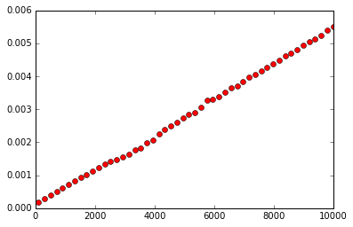

```python
%matplotlib inline
import matplotlib.pyplot as plt
import numpy as np
from timeit import timeit

def time_array_front_insert_delete(n):
    return timeit('lst.insert(0, None) ; del lst[0]',
                  'lst = list(range({}))'.format(n),
                  number=1000)

ns = np.linspace(100, 10000, 50)
plt.plot(ns, [time_array_front_insert_delete(int(n)) for n in ns], 'ro')
plt.show()
```

**Problem**: arrays are not efficient for insertions & deletions (except for at the end).

... and these types of operations can be critical for structures where, say, some internal ordering must be preserved while adding elements (e.g., a database whose records are sorted/searchable by key)

```python
# consider:

def concatenate(arr1, arr2):
    """Concatenates the contents of arr1 and arr2 as efficiently (time-wise)
    as possible, so that the resulting structure can be used to index all
    combined elements (arr1's followed by arr2's)."""

    # option 1:
    for x in arr2:
        arr1.append(x)
    return arr1

    # option 2:
    arr1.extend(arr2)
    return arr1

    # option 3:
    return arr1 + arr2
```

All options for `concatenate` are = $O(n)$, where $n$ is the number of elements involved.

**Problem**: all elements must be *contiguous* (in memory) in an array, as they are indexed from a common base address. No simple way to "bridge" the contents of two disjoint arrays --- i.e., no way to make `arr1[len(arr1)]` somehow "jump" to `arr2[0]`.

... this makes it so separately allocated, large structures cannot be merged or uniformly indexed efficiently (without first performing an expensive "defragmentation" operation to physically move the structures next to each other).

## 2. Objectives

We need a new data storage mechanism for constructing data structures that:

- does not require monolithic, contiguous memory allocation,
- allows individual elements to be flexibly and efficiently reorganized,
- and preserves the ability to locate (e.g., via position) and iterate over elements

## 3. Mechanisms

### 3.1. Two-Element Lists

```python
# data items
i1 = 'lions'
i2 = 'tigers'
i3 = 'bears'
i4 = 'oh, my'
```

```python
link1 = [i1, None]
link2 = [i2, None]
link3 = [i3, None]
link4 = [i4, None]
```

```python
link1[1] = link2
link2[1] = link3
link3[1] = link4
```

```python
def link_iter(head):
    while head:
        yield head[0]
        head = head[1]
```

```python
for i in link_iter(link1):
    print(i)
```

```
lions
tigers
bears
oh, my
```

```python
link0 = ['walruses', link1]
```

```python
for i in link_iter(link0):
    print(i)
```

```
walruses
lions
tigers
bears
oh, my
```

```python
link2[1] = ['goats', link2[1]]
```

```python
for i in link_iter(link0):
    print(i)
```

```
walruses
lions
tigers
goats
bears
oh, my
```

### 3.2. "Link" objects

```python
class Link:
    def __init__(self, val, next=None):
        self.val = val
        self.next = next
```

```python
head = Link(i4)
head = Link(i3, head)
head = Link(i2, head)
head = Link(i1, head)
```

```python
def linked_list_iter(lst):
    while lst:
        yield lst.val
        lst = lst.next
```

```python
for i in linked_list_iter(linked_lst):
    print(i)
```

```
lions
tigers
bears
oh, my
```

```python
# recursive implementation (note: recursive call obviates need for the loop)
def linked_list_iter(lst):
    if lst:
        yield lst.val
        yield from linked_list_iter(lst.next)
```

```python
for i in linked_list_iter(linked_lst):
    print(i)
```

```
lions
tigers
bears
oh, my
```

```python
class LinkedList:
    def __init__(self):
        self.head = None

    def prepend(self, val):
        self.head = Link(val, self.head)

    def __iter__(self):
        cursor = self.head
        while cursor:
            yield cursor.val
            cursor = cursor.next

    def __repr__(self):
        return '[' + ', '.join(str(x) for x in self) + ']'
```

```python
lst = LinkedList()
for i in range(10):
    lst.prepend(i)
```

```python
lst
```

```
[9, 8, 7, 6, 5, 4, 3, 2, 1, 0]
```

```python
lst2 = LinkedList()
for i in range(10, 20):
    lst2.prepend(i)

p = lst2.head
while p.next: # advance p to last node in lst2
    p = p.next

p.next = lst.head
```

```python
lst2
```

```
[19, 18, 17, 16, 15, 14, 13, 12, 11, 10, 9, 8, 7, 6, 5, 4, 3, 2, 1, 0]
```

```python
class BinaryLink:
    def __init__(self, val, left=None, right=None):
        self.val = val
        self.left = left
        self.right = right
```

```python
root = BinaryLink(10)
root.left = BinaryLink(20)
root.left.left = BinaryLink(15)
root.right = BinaryLink(30)
root.right.right = BinaryLink(45)
```

```python
def tree_iter(root):
    if root:
        yield root.val
        yield from tree_iter(root.left)
        yield from tree_iter(root.right)
```

```python
for i in tree_iter(root):
    print(i)
```

```
10
20
15
30
45
```

```python
class NaryLink:
    def __init__(self, val, n=2):
        self.val = val
        self.children = [None] * n

    def __getitem__(self, idx):
        return self.children[idx]

    def __setitem__(self, idx, val):
        self.children[idx] = val

    def __iter__(self):
        for c in self.children:
            yield c
```

```python
root = NaryLink('Kingdoms', n=5)

root[0] = NaryLink('Animalia', n=35)
root[1] = NaryLink('Plantae', n=12)
root[2] = NaryLink('Fungi', n=7)
root[3] = NaryLink('Protista', n=5)
root[4] = NaryLink('Monera', n=5)

root[2][0] = NaryLink('Chytridiomycota')
root[2][1] = NaryLink('Blastocladiomycota')
root[2][2] = NaryLink('Glomeromycota')
root[2][3] = NaryLink('Ascomycota')
root[2][4] = NaryLink('Basidiomycota')
root[2][5] = NaryLink('Microsporidia')
root[2][6] = NaryLink('Neocallimastigomycota')

def tree_iter(root):
    if root:
        yield root.val
        for c in root:
            yield from tree_iter(c)
```

```python
for x in tree_iter(root):
    print(x)
```

```
Kingdoms
Animalia
Plantae
Fungi
Chytridiomycota
Blastocladiomycota
Glomeromycota
Ascomycota
Basidiomycota
Microsporidia
Neocallimastigomycota
Protista
Monera
```